# Dealing with large datasets: dimensional reduction

Working with Next Generation Sequencing techniques will most of the time involve dealing with massive amounts of data. From tables storing read counts of each transcript to genome-wide annotation databases, being able to extract meaningful information from thousands or millions of individual data points will be severely restricted by the capacity to process information that is available. Because of this, one of the first concerns when designing a data analysis strategy will be condensing the information as much as possible.

### Separating the grain from the chaff

When planning an experiment, specially if the costs are high, often times one of the priorities will be to gather as much information as possible. In addition to that, we will frequently want to incorporate to our analysis resources and datasets generated by other teams, who could have had different goals, and so, different preferences when choosing what information to store and share.

In light of that, one of our first steps when doing data analysis will be measuring how relevant or informative is each piece of data to our question in order to keep only what’s useful to us, and so, avoid spending unnecessary time and resources.

In the context of single-cell RNA-seq one of the most straightforward examples of this is filtering «*low quality*» cells. After capturing the RNA of each individualized cell, tagging, amplifying, sequencing it, and mapping each read to the transcriptome we end up with a table of read counts for each gene and cell, and then:

- We define measures of quality related to how representative of a real cell could a list of gene counts be: how many mRNAs were captured, how many different genes were detected, etc.
- We set criteria for this measures of quality so that the cells that don’t meet them are not considered representative enough, and thus, not useful to characterize the sample that is being studied.

In the general field of data science there’s a variety of techniques to filter out outliers or to find the most relevant features of a dataset. The method we choose will depend on:

- The type of data: numerical (continuous, discrete… ), categorical ( nominal, ordinal…)
- The task being performed: do we want to separate the elements of the dataset into groups? generate a predictive model for new data? How we can measure the relevance of a feature will change depending on whether we start from the get go with separated groups of information or not.

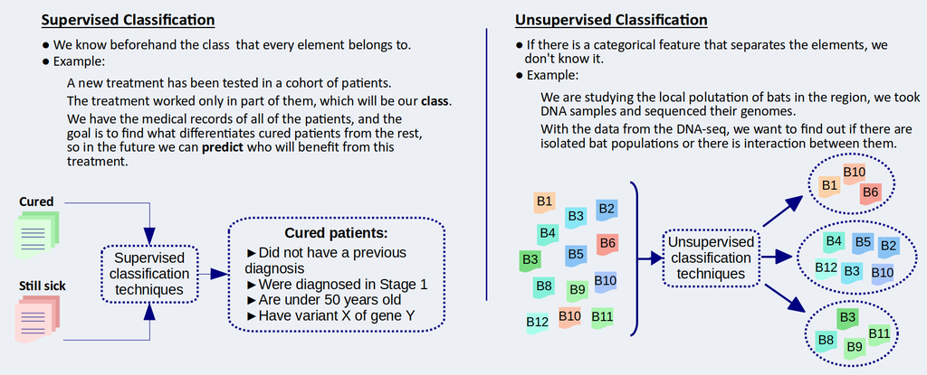

### Condensing information

Besides excluding the elements or features that are deemed less useful, there are other ways to reduce the amount of data that needs to be store while keeping the relevant information that describes our dataset. For example, some features might be correlated, like genes regulated by the same transcription factors.

#### Principal Component Analysis

Using Principal Component Analysis, or PCA, our goal will be to reduce the number of features that characterize our dataset while keeping all the variability between elements that we can.

The resulting new features are what is called *Principal Components*. A principal component is a linear combination of features of our dataset:

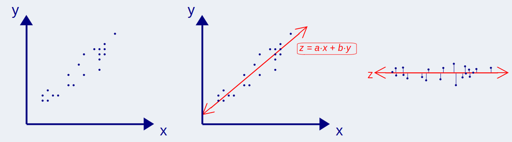

*Graphical example of PCA: a dataset is described by two features, **X** and **Y**. The function **Z** represents the direction in which there is more variability. For each point, we can calculate the value of the new feature **Z**. Now, we can describe our set of points using only the value in **Z**, keeping most of the variability in original information.*

The algorithms implementing PCA will prioritize the features with more variability, so the first component will be the more informative, the second, a little less so, etc. Working with large datasets, like a whole transcriptome and hundreds or thousands of cells in scRNA-seq, we will always loose some information after doing a PCA, but it’s the trade-off of going from 20-30,000 features to between 10 and 50.

#### Non-linear methods: UMAP and tSNE

As with PCA, algorithms like UMAP and tSNE have the goal of summarize the information given by large numbers of features. The advantage of this two methods is that they are much more efficient at capturing the local underlying structure of the data and presenting it in just two dimensions:

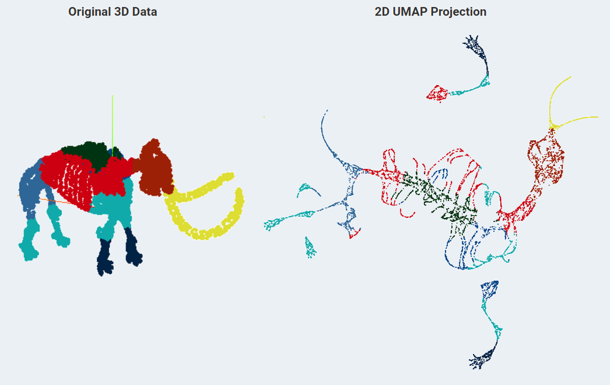

*On the left side, points arranged in a 3D representation of a woolly mammoth skeleton. On the right side, a corresponding UMAP projection of the points in 2D. ([Source](https://pair-code.github.io/understanding-umap/))*

Notice how, in the example above, the points that form the spine or the ribs are kept connected, as well as the groups of points that form each leg or the tusks and head. When talking about keeping «*the local structure*», this is what we mean: the skeleton as a whole could end up arranged in an awkward position, but most points will end up placed with their closest neighbors, and most importantly positioned in such a way that we can see all points of the dataset at the same time. These two aspects are what makes tSNE and UMAP projections such incredibly powerful tools to help visualize and display information about high-dimensional datasets like our scRNA-seq experiments.

Often times there is a trade off between keeping the local and global structures, and that is one of the key difference beteen these two methods: UMAP was developed to improve upon tSNE, so it will generally be better an preserving the global relationships in the dataset, in addition to decreasing considerabli the time neede to run the algorithm.

The key differences between PCA and tSNE / UMAP methods are:

- While PCA condenses features by generating a *linear* combinations, UMAP and tSNE use *non-linear* transformations:

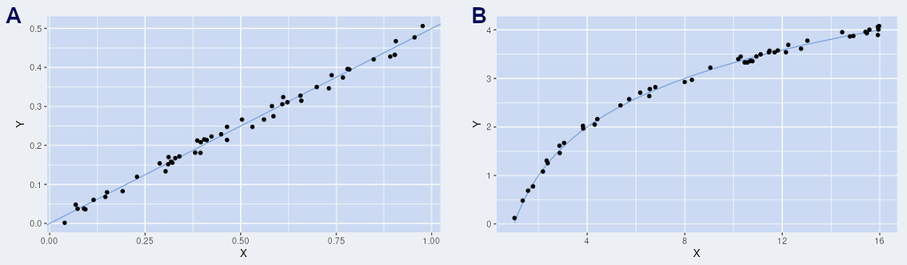

*Example of linear (A) and non-linear (B) relationships between two features.*

- Both tSNE and UMAP are iterative algorithms: they run for several cycles, making small changes that improve the result at each step:

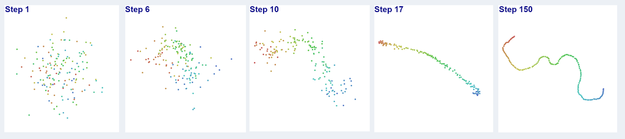

*State of a tSNE run at several steps of the process.*

In the context of single cell RNA-seq, oftentimes the relationships between genes will be closer to non-linear than linear, so tSNE and UMAP will be capable of capturing those relationships better than a PCA. Although, it’s important to keep in mind that condensing the expression of thousands of genes into just two variables will necessarily lead to loosing a lot of information, so be cautious when interpreting a 2D projection of the cells of scRNA-seq experiments.

Another important aspect of tSNE and UMAP algorithms is that, like many other methods to work with large datasets, the optimization process is not totally comprehensive -it does not examine every possible solution to a problem-, and there is a certain degree of stochasticity on the particular result it returns. To keep reproducibility, both algorithms are implemented to always return the same solution for a dataset and set of parameters *unless the user demands otherwise explicitly*, but it’s important to keep in mind that the 2D projections that we get will always be *one of the many possible ways to project the information of the dataset into 2 dimensions*.

**More resources**

- [Interactive examples of PCA](https://setosa.io/ev/principal-component-analysis/)
- Interactive guides to interpret [t-SNE](https://distill.pub/2016/misread-tsne/) and [UMAP](https://pair-code.github.io/understanding-umap/) projections.